[figure not shown]

# Active Lives Adult Survey

Somerset and England · 2024/25 · Working draft

## Executive summary

[figure not shown]

**About the data and how to use this report**

These are weighted estimates from Sport England’s Active Lives Survey. Each measure uses eligible respondents with valid answers and an approved positive weight.

Select Somerset, England or both; select groups; switch between current-year charts, trends and tables. Download PNG saves the displayed chart. England uses blue shades, hatched bars and dashed trend lines.

For wellbeing and motivation, choose whether percentages are calculated within each response category or within each activity group. Filtering visible groups does not recalculate denominators.

Changes are descriptive and are not significance tests. Missing values are not zero.

In 2024/25, **68.0%** were active in Somerset, compared with **64.6%** in England.

The local active percentage changed by **+4.2 percentage points** from 2023/24 (63.8%). This is a descriptive comparison.

## Levels of activity

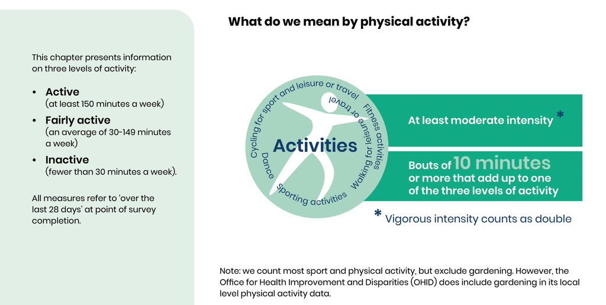

**Overall activity**

**Overall activity by Gender**

**Overall activity by Age**

**Overall activity by Socioeconomic group**

**Overall activity by Disability**

**Overall activity by Ethnicity**

## Muscle strengthening

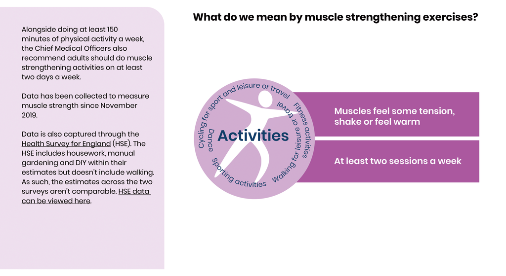

**Muscle strengthening**

**Muscle strengthening by Gender**

**Muscle strengthening by Age**

**Muscle strengthening by Socioeconomic group**

**Muscle strengthening by Disability**

**Muscle strengthening by Ethnicity**

## Types of activity

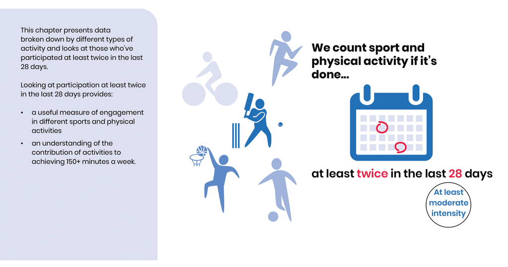

**Participation by activity type**

Participated at least twice in the last 28 days. Each activity is a separate measure; percentages do not sum to 100%.

## Wellbeing and development

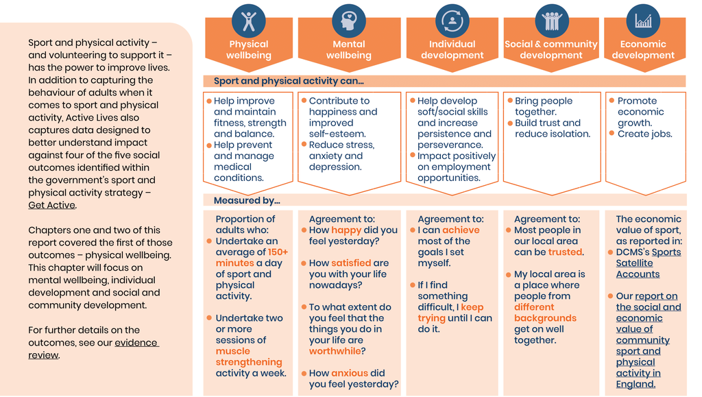

**Anxiety**

**Anxiety and activity level**

Show percentages within

**Anxiety and activity level**

**Happiness**

**Happiness and activity level**

Show percentages within

**Happiness and activity level**

**Loneliness**

**Loneliness and activity level**

Show percentages within

**Loneliness and activity level**

**Life satisfaction**

**Life satisfaction and activity level**

Show percentages within

**Life satisfaction and activity level**

**Feeling worthwhile**

**Feeling worthwhile and activity level**

Show percentages within

**Feeling worthwhile and activity level**

**Number of high wellbeing scores**

**Number of high wellbeing scores and activity level**

Show percentages within

**Number of high wellbeing scores and activity level**

**Most people in my local area can be trusted agreement (grouped)**

**Most people in my local area can be trusted agreement (grouped) and activity level**

Show percentages within

**Most people in my local area can be trusted agreement (grouped) and activity level**

**My local area is a place where people from different backgrounds get on well together strongly agree/ not strongly agree (grouped)**

**My local area is a place where people from different backgrounds get on well together strongly agree/ not strongly agree (grouped) and activity level**

Show percentages within

**My local area is a place where people from different backgrounds get on well together strongly agree/ not strongly agree (grouped) and activity level**

**I can achieve most of the goals I set myself agreement (grouped)**

**I can achieve most of the goals I set myself agreement (grouped) and activity level**

Show percentages within

**I can achieve most of the goals I set myself agreement (grouped) and activity level**

**If I find something difficult, keep trying until I can do it? (grouped)**

**If I find something difficult, keep trying until I can do it? (grouped) and activity level**

Show percentages within

**If I find something difficult, keep trying until I can do it? (grouped) and activity level**

## Attitudes and motivation

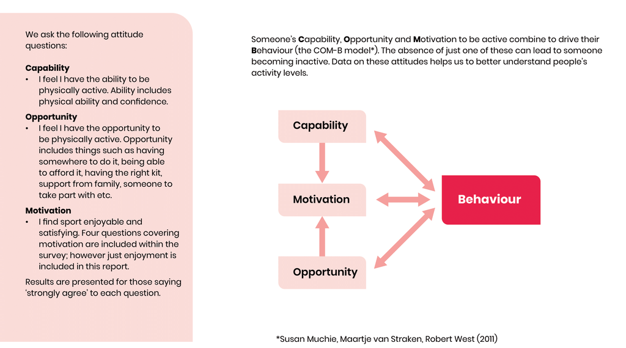

**Readiness for activity: Ability (REBASED & GROUPED)**

**Readiness for activity: Ability (REBASED & GROUPED) and activity level**

Show percentages within

**Readiness for activity: Ability (REBASED & GROUPED) and activity level**

**Readiness for activity: Opportunity (REBASED & GROUPED)**

**Readiness for activity: Opportunity (REBASED & GROUPED) and activity level**

Show percentages within

**Readiness for activity: Opportunity (REBASED & GROUPED) and activity level**

**Motivation for sport/exercise: I find sport/exercise enjoyable and satisfying (REBASED & GROUPED)**

**Motivation for sport/exercise: I find sport/exercise enjoyable and satisfying (REBASED & GROUPED) and activity level**

Show percentages within

**Motivation for sport/exercise: I find sport/exercise enjoyable and satisfying (REBASED & GROUPED) and activity level**

**Motivation for sport/exercise: Its important to me to do sport/exercise regularly (REBASED & GROUPED)**

**Motivation for sport/exercise: Its important to me to do sport/exercise regularly (REBASED & GROUPED) and activity level**

Show percentages within

**Motivation for sport/exercise: Its important to me to do sport/exercise regularly (REBASED & GROUPED) and activity level**

**Motivation for sport/exercise: I feel guilty when I dont do sport/exercise (REBASED & GROUPED)**

**Motivation for sport/exercise: I feel guilty when I dont do sport/exercise (REBASED & GROUPED) and activity level**

Show percentages within

**Motivation for sport/exercise: I feel guilty when I dont do sport/exercise (REBASED & GROUPED) and activity level**

**Motivation for sport/exercise: I do sport/exercise because I dont want to disappoint other people (REBASEDREBASED & GROUPED**

**Motivation for sport/exercise: I do sport/exercise because I dont want to disappoint other people (REBASEDREBASED & GROUPED and activity level**

Show percentages within

**Motivation for sport/exercise: I do sport/exercise because I dont want to disappoint other people (REBASEDREBASED & GROUPED and activity level**

**Motivation for sport/exercise: I feel that doing sport/exercise is pointless (REBASED & GROUPED)**

Current-year results await weighting review. See data notes.

**Motivation for sport/exercise: I feel that doing sport/exercise is pointless (REBASED & GROUPED) and activity level**

Show percentages within

**Motivation for sport/exercise: I feel that doing sport/exercise is pointless (REBASED & GROUPED) and activity level**

**I exercise to stay fit and healthy (GROUPED)**

**I exercise to stay fit and healthy (GROUPED) and activity level**

Show percentages within

**I exercise to stay fit and healthy (GROUPED) and activity level**

**I exercise to help me relax and worry less about things (GROUPED)**

**I exercise to help me relax and worry less about things (GROUPED) and activity level**

Show percentages within

**I exercise to help me relax and worry less about things (GROUPED) and activity level**

**I exercise socially for fun with friends (GROUPED)**

Not currently available in this dataset; historical results are retained. This does not confirm that the survey question was discontinued. See data notes.

**I exercise socially for fun with friends (GROUPED) and activity level**

Show percentages within

**I exercise socially for fun with friends (GROUPED) and activity level**

**I exercise to challenge myself (either against myself or others) (GROUPED)**

Not currently available in this dataset; historical results are retained. This does not confirm that the survey question was discontinued. See data notes.

**I exercise to challenge myself (either against myself or others) (GROUPED) and activity level**

Show percentages within

**I exercise to challenge myself (either against myself or others) (GROUPED) and activity level**

## Volunteering

[figure not shown]

**Any volunteering in the last 12 months**

**Frequency of volunteering over the last 12 months**

**Grouped: how long do you usually volunteer for in any given instance (most regular role)**

## Definitions, data notes and sources

**Definitions and interpretation**

Percentages may not sum to 100% because of rounding. Filter selections do not change denominators. Breakdown percentages use respondents with valid answers to both questions and the outcome question’s weight.

Small cells and complementary cells are suppressed. For the two-way activity comparisons, if either view requires suppression, both views for that indicator, area and year are withheld to protect the same underlying cells.

Confidence intervals are not presented because verified intervals are available for only a limited subset of results.

**Survey changes and measure availability**

**all:** Adult weights depend on the question and questionnaire group. Rows marked review in config/variables.csv are not analysed until their weight is checked; the imported data remain available. adult_2023

**2016/17:** For 2016/17, Volint_ANY contains unlabelled valid codes 0 and 1. These were interpreted as No and Yes respectively, consistent with the labelled 2017/18 and 2018/19 files. This is an analyst assumption; the supplied 2016/17 documentation does not confirm these meanings. Negative missing/routing codes were excluded from the denominator. adult_2016_volunteering_assumption

**2016/17;2017/18;2018/19;2019/20;2020/21; 2016/17;2017/18;2018/19:** Readiness was grouped as strongly agree versus other valid responses. Negative missing codes and any code 0 labelled 'Not asked' were excluded. Where respondents were skipped because they were already sufficiently active, estimates describe valid respondents to the question, not all adults. Comparisons with years using different routing require caution. adult_readiness_processing

**2017/18:** For 2017/18, anxiety categories were reconstructed from the original 0–10 score using the supplied category definitions: 0–1 very low, 2–3 low, 4–5 medium and 6–10 very high. Cross-tabulation showed that the supplied grouped variable did not consistently follow these boundaries. Negative missing codes were excluded. This is an analyst correction, not a revised data release. adult_2017_anxiety_regrouping

**2017/18:** For 2017/18, happiness categories were reconstructed from the original 0–10 score using the supplied category definitions: 0–4 low, 5–6 medium, 7–8 high and 9–10 very high. Cross-tabulation showed that the supplied grouped variable did not consistently follow these boundaries. Negative missing codes were excluded. This is an analyst correction, not a revised data release. adult_2017_happiness_regrouping

**2017/18:** Life satisfaction categories for 2017/18 were reconstructed from the original 0–10 score using the supplied definitions: 0–4 low, 5–6 medium, 7–8 high and 9–10 very high. Cross-tabulation showed that the supplied grouped variable did not consistently follow these boundaries. Negative missing codes were excluded. This is an analyst correction, not a revised data release. adult_2017_lifesat_regrouping

**2017/18:** Worthwhile categories for 2017/18 were reconstructed from the original 0–10 score using the supplied definitions: 0–4 low, 5–6 medium, 7–8 high and 9–10 very high. Cross-tabulation showed that the supplied grouped variable did not consistently follow these boundaries. Negative missing codes were excluded. This is an analyst correction, not a revised data release. adult_2017_worthw_regrouping

**2016/17; 2017/18:** Readiness was asked below the questionnaire-calculated 150-minute weekly activity threshold. Percentages describe eligible respondents with valid answers, not all adults. Routing exclusions and other missing responses are excluded. These estimates use wt_final_online; comparisons with years using broader question eligibility are not like-for-like. adult_2016_online_questionnaire; adult_2017_online_questionnaire

**2017/18:** Report-author-approved analytical decision: retain 20 valid responses labelled PAPER, all with positive supplied online weights. The reason for the mode discrepancy is unresolved; retention is not a confirmed Sport England instruction. adult_2026_review_decisions

**2016/17;2017/18;2018/19;2019/20;2020/21;2021/22;2022/23:** Percentages describe strong agreement among eligible respondents with valid answers to item E, not among all adults. The reviewed questionnaires ask E only after neutral/disagree/strongly disagree responses to all preceding motivation items A-D. Respondents not asked and other missing responses are excluded, not counted as disagreeing. Analysis uses wt_final_online. This conditional denominator is the analytical approach adopted for this report. adult_2026_review_decisions

**2016/17; 2017/18:** The questionnaire routes item E on both the sport and exercise branches to respondents selecting response 3, 4 or 5 on each of A-D. adult_2016_online_questionnaire; adult_2017_online_questionnaire

**2017/18:** Analytical decision: retain eight valid PAPER-labelled responses with positive supplied online weights, following the report-author-approved approach to the readiness mode discrepancy. Their origin remains unresolved. adult_2026_review_decisions

**2020/21:** 2020/21 loneliness estimates are temporarily omitted. The Year 6 User Guide specifies wt_lone, but that weight was not found in the directly shared dataset. The appropriate weight for this file remains unresolved. adult_2020

**2018/19:** 2018/19 loneliness uses wt_final_C, the online group 2 weight, as specified in the Year 4 User Guide, Table 6. All 52,502 valid responses in the supplied file are online and have positive values for this weight. Percentages exclude routing exclusions and other missing responses. adult_2018

**2019/20:** 2019/20 loneliness uses wt_final_AB: postal and online group 1. Online group 2 responses are excluded because question-order effects made them incomparable, as explained in the technical report. Missing responses and non-positive or missing weights are excluded. adult_2019_technical_loneliness

**2015/16, 2016/17, 2017/18, 2018/19, 2019/20, 2020/21: Anxiety; Happiness; Loneliness; Life satisfaction; Feeling worthwhile; Number of high wellbeing scores; Num sessions of moderate activity for at least 10 minutes in last 28 days with 60 min limit (grouped): Cycling for leisure and sport; Num sessions of moderate activity for at least 10 minutes in last 28 days with 60 min limit (grouped): Fitness activities; Muscle strengthening; Readiness for activity: Ability (REBASED & GROUPED); Readiness for activity: Opportunity (REBASED & GROUPED); Motivation for sport/exercise: I find sport/exercise enjoyable and satisfying (REBASED & GROUPED); Motivation for sport/exercise: Its important to me to do sport/exercise regularly (REBASED & GROUPED); Motivation for sport/exercise: I feel guilty when I dont do sport/exercise (REBASED & GROUPED); Motivation for sport/exercise: I do sport/exercise because I dont want to disappoint other people (REBASEDREBASED & GROUPED; Motivation for sport/exercise: I feel that doing sport/exercise is pointless (REBASED & GROUPED); I exercise to stay fit and healthy (GROUPED); I exercise to help me relax and worry less about things (GROUPED); I exercise socially for fun with friends (GROUPED); I exercise to challenge myself (either against myself or others) (GROUPED); Most people in my local area can be trusted agreement (grouped); My local area is a place where people from different backgrounds get on well together strongly agree/ not strongly agree (grouped); I can achieve most of the goals I set myself agreement (grouped); If I find something difficult, keep trying until I can do it? (grouped); Any volunteering in the last 12 months; Frequency of volunteering over the last 12 months; Grouped: how long do you usually volunteer for in any given instance (most regular role).** Requested source name absent from this dictionary; do not assume the question was not asked. No substitute approved.

**2015/16: Num sessions of moderate activity for at least 10 minutes in last 28 days with 60 min limit (grouped): Active Travel; Num sessions of moderate activity for at least 10 minutes in last 28 days with 60 min limit (grouped): Walking for leisure; Num sessions of moderate activity for at least 10 minutes in last 28 days with 60 min limit (grouped): Team sports; Num sessions of moderate activity for at least 10 minutes in last 28 days with 60 min limit (grouped): Swimming; Num sessions of moderate activity for at least 10 minutes in last 28 days with 60 min limit (grouped): Running or jogging.** Weight reviewed against the 2015/16 Year 1 Data User Guide, Weighting section and Table 4, and valid-response counts by Mode among adults aged 16+ in the supplied dataset. These combined-mode measures use wt_final.

**2016/17, 2017/18, 2018/19, 2019/20: Number of high wellbeing scores.** Combined wellbeing measure absent from the supplied file. The four individual wellbeing measures are available; the combined measure has not been derived.

**2016/17: Num sessions of moderate activity for at least 10 minutes in last 28 days with 60 min limit (grouped): Active Travel; Num sessions of moderate activity for at least 10 minutes in last 28 days with 60 min limit (grouped): Cycling for leisure and sport; Num sessions of moderate activity for at least 10 minutes in last 28 days with 60 min limit (grouped): Walking for leisure; Num sessions of moderate activity for at least 10 minutes in last 28 days with 60 min limit (grouped): Team sports; Num sessions of moderate activity for at least 10 minutes in last 28 days with 60 min limit (grouped): Swimming; Num sessions of moderate activity for at least 10 minutes in last 28 days with 60 min limit (grouped): Running or jogging; Num sessions of moderate activity for at least 10 minutes in last 28 days with 60 min limit (grouped): Fitness activities; Motivation for sport/exercise: I find sport/exercise enjoyable and satisfying (REBASED & GROUPED); Motivation for sport/exercise: Its important to me to do sport/exercise regularly (REBASED & GROUPED); Motivation for sport/exercise: I feel guilty when I dont do sport/exercise (REBASED & GROUPED); Motivation for sport/exercise: I do sport/exercise because I dont want to disappoint other people (REBASEDREBASED & GROUPED.** Weight reviewed against the 2016/17 Year 2 Data User Guide, Weighting section and Table 6, and valid-response counts by Mode among adults aged 16+ in the supplied dataset. These combined-mode measures use wt_final.

**2016/17: Readiness for activity: Ability (REBASED & GROUPED); Readiness for activity: Opportunity (REBASED & GROUPED).** 2016/17 readiness: use wt_final_online. The online questionnaire, Readiness section (PDF pp. 24-25), asks READYAB1/READYOP1 below its calculated 150-minute activity threshold; readiness is not restricted to a questionnaire group. In the supplied file, substantive responses occur only online. Estimates describe eligible respondents with valid answers, not all adults. Routing and other missing responses are excluded. Source: 8391_active_lives_adult_online_questionnaire_scripting_internal_and_client.pdf. Weighting source: Year 2 Data User Guide, Table 6.

**2016/17, 2018/19, 2019/20, 2020/21, 2021/22, 2022/23: Motivation for sport/exercise: I feel that doing sport/exercise is pointless (REBASED & GROUPED).** Use wt_final_online for motivation item E. Report strong agreement among eligible respondents with valid answers, not among all adults. The reviewed online questionnaires route item E to respondents selecting neutral/disagree/strongly disagree on all four preceding motivation items A-D. Respondents not asked and other missing responses remain excluded; they are not classified as disagreeing. All included responses in the supplied annual file have positive online weights.

**2017/18: Num sessions of moderate activity for at least 10 minutes in last 28 days with 60 min limit (grouped): Active Travel; Num sessions of moderate activity for at least 10 minutes in last 28 days with 60 min limit (grouped): Cycling for leisure and sport; Num sessions of moderate activity for at least 10 minutes in last 28 days with 60 min limit (grouped): Walking for leisure; Num sessions of moderate activity for at least 10 minutes in last 28 days with 60 min limit (grouped): Team sports; Num sessions of moderate activity for at least 10 minutes in last 28 days with 60 min limit (grouped): Swimming; Num sessions of moderate activity for at least 10 minutes in last 28 days with 60 min limit (grouped): Running or jogging; Num sessions of moderate activity for at least 10 minutes in last 28 days with 60 min limit (grouped): Fitness activities; Motivation for sport/exercise: I find sport/exercise enjoyable and satisfying (REBASED & GROUPED); Motivation for sport/exercise: Its important to me to do sport/exercise regularly (REBASED & GROUPED); Motivation for sport/exercise: I feel guilty when I dont do sport/exercise (REBASED & GROUPED); Motivation for sport/exercise: I do sport/exercise because I dont want to disappoint other people (REBASEDREBASED & GROUPED.** Weight reviewed against the 2017/18 Year 3 Data User Guide, Weighting section and Table 6, and valid-response counts by Mode in the supplied dataset. These combined-mode measures use wt_final.

**2017/18: Readiness for activity: Ability (REBASED & GROUPED); Readiness for activity: Opportunity (REBASED & GROUPED).** 2017/18 readiness: use wt_final_online. The Year 3 online questionnaire, Readiness section (PDF pp. 26-27), restricts these questions to respondents below its calculated 150-minute activity threshold. Estimates describe eligible respondents with valid answers, not all adults. Routing and other missing responses are excluded. Analyst decision: retain the 20 valid responses labelled PAPER for each measure; all have positive supplied online weights. Their mode discrepancy remains unexplained. This retention decision was approved by the report author; it is not a confirmed explanation from Sport England.

**2017/18: Motivation for sport/exercise: I feel that doing sport/exercise is pointless (REBASED & GROUPED).** Use wt_final_online for motivation item E. Report strong agreement among eligible respondents with valid answers, not among all adults. The reviewed online questionnaires route item E to respondents selecting neutral/disagree/strongly disagree on all four preceding motivation items A-D. Respondents not asked and other missing responses remain excluded; they are not classified as disagreeing. All included responses in the supplied annual file have positive online weights. Analyst decision: retain eight valid PAPER-labelled responses with positive supplied online weights, following the agreed approach to the 2017/18 readiness anomaly. The mode discrepancy remains unexplained.

**2018/19: Loneliness.** 2018/19 loneliness uses wt_final_C, the online group 2 weight, as specified in the Year 4 User Guide, Table 6. All 52,502 valid responses in the supplied file are online and have positive values for this weight. Percentages exclude routing exclusions and other missing responses.

**2018/19: Num sessions of moderate activity for at least 10 minutes in last 28 days with 60 min limit (grouped): Active Travel; Num sessions of moderate activity for at least 10 minutes in last 28 days with 60 min limit (grouped): Cycling for leisure and sport; Num sessions of moderate activity for at least 10 minutes in last 28 days with 60 min limit (grouped): Walking for leisure; Num sessions of moderate activity for at least 10 minutes in last 28 days with 60 min limit (grouped): Team sports; Num sessions of moderate activity for at least 10 minutes in last 28 days with 60 min limit (grouped): Swimming; Num sessions of moderate activity for at least 10 minutes in last 28 days with 60 min limit (grouped): Running or jogging; Num sessions of moderate activity for at least 10 minutes in last 28 days with 60 min limit (grouped): Fitness activities; Readiness for activity: Ability (REBASED & GROUPED); Readiness for activity: Opportunity (REBASED & GROUPED); Motivation for sport/exercise: I find sport/exercise enjoyable and satisfying (REBASED & GROUPED); Motivation for sport/exercise: Its important to me to do sport/exercise regularly (REBASED & GROUPED); Motivation for sport/exercise: I feel guilty when I dont do sport/exercise (REBASED & GROUPED); Motivation for sport/exercise: I do sport/exercise because I dont want to disappoint other people (REBASEDREBASED & GROUPED.** Weight reviewed against the 2018/19 Year 4 Data User Guide, Weighting section and Table 6, and valid-response counts by Mode in the supplied dataset. These combined-mode measures use wt_final.

**2019/20: Loneliness.** 2019/20 loneliness uses wt_final_AB: postal and online group 1. Online group 2 responses are excluded because question-order effects made them incomparable, as explained in the technical report. Missing responses and non-positive or missing weights are excluded.

**2019/20: Num sessions of moderate activity for at least 10 minutes in last 28 days with 60 min limit (grouped): Active Travel; Num sessions of moderate activity for at least 10 minutes in last 28 days with 60 min limit (grouped): Cycling for leisure and sport; Num sessions of moderate activity for at least 10 minutes in last 28 days with 60 min limit (grouped): Walking for leisure; Num sessions of moderate activity for at least 10 minutes in last 28 days with 60 min limit (grouped): Team sports; Num sessions of moderate activity for at least 10 minutes in last 28 days with 60 min limit (grouped): Swimming; Num sessions of moderate activity for at least 10 minutes in last 28 days with 60 min limit (grouped): Running or jogging; Num sessions of moderate activity for at least 10 minutes in last 28 days with 60 min limit (grouped): Fitness activities; Readiness for activity: Ability (REBASED & GROUPED); Motivation for sport/exercise: I find sport/exercise enjoyable and satisfying (REBASED & GROUPED); Motivation for sport/exercise: Its important to me to do sport/exercise regularly (REBASED & GROUPED); Motivation for sport/exercise: I feel guilty when I dont do sport/exercise (REBASED & GROUPED); Motivation for sport/exercise: I do sport/exercise because I dont want to disappoint other people (REBASEDREBASED & GROUPED; Grouped: how long do you usually volunteer for in any given instance (most regular role).** Weight reviewed against the 2019/20 Year 5 Data User Guide, Weighting section and Table 5, and valid-response counts by Mode in the supplied dataset. Combined-mode measures use wt_final; online-only volunteering duration uses wt_final_online.

**2020/21: Loneliness.** 2020/21 loneliness estimates are temporarily omitted. The Year 6 User Guide specifies wt_lone, but that weight was not found in the directly shared dataset. The appropriate weight for this file remains unresolved.

**2020/21: Num sessions of moderate activity for at least 10 minutes in last 28 days with 60 min limit (grouped): Active Travel; Num sessions of moderate activity for at least 10 minutes in last 28 days with 60 min limit (grouped): Cycling for leisure and sport; Num sessions of moderate activity for at least 10 minutes in last 28 days with 60 min limit (grouped): Walking for leisure; Num sessions of moderate activity for at least 10 minutes in last 28 days with 60 min limit (grouped): Team sports; Num sessions of moderate activity for at least 10 minutes in last 28 days with 60 min limit (grouped): Swimming; Num sessions of moderate activity for at least 10 minutes in last 28 days with 60 min limit (grouped): Running or jogging; Num sessions of moderate activity for at least 10 minutes in last 28 days with 60 min limit (grouped): Fitness activities; Readiness for activity: Ability (REBASED & GROUPED); Motivation for sport/exercise: I find sport/exercise enjoyable and satisfying (REBASED & GROUPED); Motivation for sport/exercise: Its important to me to do sport/exercise regularly (REBASED & GROUPED); Motivation for sport/exercise: I feel guilty when I dont do sport/exercise (REBASED & GROUPED); Motivation for sport/exercise: I do sport/exercise because I dont want to disappoint other people (REBASEDREBASED & GROUPED; I exercise to stay fit and healthy (GROUPED); I exercise to help me relax and worry less about things (GROUPED); I exercise socially for fun with friends (GROUPED); I exercise to challenge myself (either against myself or others) (GROUPED); Grouped: how long do you usually volunteer for in any given instance (most regular role).** Weight reviewed against the 2020/21 Year 6 Data User Guide, Weighting section and Table 5, and valid-response counts by Mode in the supplied dataset. Combined-mode measures use wt_final; online-only volunteering duration uses wt_final_online.

**2021/22: Num sessions of moderate activity for at least 10 minutes in last 28 days with 60 min limit (grouped): Active Travel; Num sessions of moderate activity for at least 10 minutes in last 28 days with 60 min limit (grouped): Cycling for leisure and sport; Num sessions of moderate activity for at least 10 minutes in last 28 days with 60 min limit (grouped): Walking for leisure; Num sessions of moderate activity for at least 10 minutes in last 28 days with 60 min limit (grouped): Team sports; Num sessions of moderate activity for at least 10 minutes in last 28 days with 60 min limit (grouped): Swimming; Num sessions of moderate activity for at least 10 minutes in last 28 days with 60 min limit (grouped): Running or jogging; Num sessions of moderate activity for at least 10 minutes in last 28 days with 60 min limit (grouped): Fitness activities; Readiness for activity: Ability (REBASED & GROUPED); Readiness for activity: Opportunity (REBASED & GROUPED); Motivation for sport/exercise: I find sport/exercise enjoyable and satisfying (REBASED & GROUPED); Motivation for sport/exercise: Its important to me to do sport/exercise regularly (REBASED & GROUPED); Motivation for sport/exercise: I feel guilty when I dont do sport/exercise (REBASED & GROUPED); Motivation for sport/exercise: I do sport/exercise because I dont want to disappoint other people (REBASEDREBASED & GROUPED; I exercise to stay fit and healthy (GROUPED); I exercise to help me relax and worry less about things (GROUPED); I exercise socially for fun with friends (GROUPED); I exercise to challenge myself (either against myself or others) (GROUPED); Grouped: how long do you usually volunteer for in any given instance (most regular role).** Weight reviewed against the 2021/22 Year 7 User Guide: Weighting section and Table 5, plus valid-response counts by Mode in the supplied file. Combined-mode measures use wt_final; online-only volunteering duration uses wt_final_online.

**2022/23: Num sessions of moderate activity for at least 10 minutes in last 28 days with 60 min limit (grouped): Active Travel; Num sessions of moderate activity for at least 10 minutes in last 28 days with 60 min limit (grouped): Cycling for leisure and sport; Num sessions of moderate activity for at least 10 minutes in last 28 days with 60 min limit (grouped): Walking for leisure; Num sessions of moderate activity for at least 10 minutes in last 28 days with 60 min limit (grouped): Team sports; Num sessions of moderate activity for at least 10 minutes in last 28 days with 60 min limit (grouped): Swimming; Num sessions of moderate activity for at least 10 minutes in last 28 days with 60 min limit (grouped): Running or jogging; Num sessions of moderate activity for at least 10 minutes in last 28 days with 60 min limit (grouped): Fitness activities; Readiness for activity: Ability (REBASED & GROUPED); Readiness for activity: Opportunity (REBASED & GROUPED); Motivation for sport/exercise: I find sport/exercise enjoyable and satisfying (REBASED & GROUPED); Motivation for sport/exercise: Its important to me to do sport/exercise regularly (REBASED & GROUPED); Motivation for sport/exercise: I feel guilty when I dont do sport/exercise (REBASED & GROUPED); Motivation for sport/exercise: I do sport/exercise because I dont want to disappoint other people (REBASEDREBASED & GROUPED; I exercise to stay fit and healthy (GROUPED); I exercise to help me relax and worry less about things (GROUPED); I exercise socially for fun with friends (GROUPED); I exercise to challenge myself (either against myself or others) (GROUPED); Grouped: how long do you usually volunteer for in any given instance (most regular role).** Weight reviewed against the 2022/23 Year 8 User Guide: Weighting section and Table 5, plus valid-response counts by Mode in the supplied file. Combined-mode measures use wt_final; online-only volunteering duration uses wt_final_online.

**2015/16, 2016/17: Aged 16 and over.** Restrict adult analyses to Age16plus = 1.

**2019/20: Postal & Online Group 1.** Required for 2019/20 loneliness analysis.

**2024/25: Gender; Ethnicity; Ethnicity - grouped; Age - three bands; Age; Age - nine bands; NS-SEC - grouped to four categories; Socioeconomic group; Disability; Anxiety; Happiness; Loneliness; Life satisfaction; Feeling worthwhile; Number of high wellbeing scores; Overall activity; Num sessions of moderate activity for at least 10 minutes in last 28 days with 60 min limit (grouped): Active Travel; Num sessions of moderate activity for at least 10 minutes in last 28 days with 60 min limit (grouped): Cycling for leisure and sport; Num sessions of moderate activity for at least 10 minutes in last 28 days with 60 min limit (grouped): Walking for leisure; Num sessions of moderate activity for at least 10 minutes in last 28 days with 60 min limit (grouped): Team sports; Num sessions of moderate activity for at least 10 minutes in last 28 days with 60 min limit (grouped): Swimming; Num sessions of moderate activity for at least 10 minutes in last 28 days with 60 min limit (grouped): Running or jogging; Num sessions of moderate activity for at least 10 minutes in last 28 days with 60 min limit (grouped): Fitness activities; Muscle strengthening; Readiness for activity: Ability (REBASED & GROUPED); Readiness for activity: Opportunity (REBASED & GROUPED); Motivation for sport/exercise: I find sport/exercise enjoyable and satisfying (REBASED & GROUPED); Motivation for sport/exercise: Its important to me to do sport/exercise regularly (REBASED & GROUPED); Motivation for sport/exercise: I feel guilty when I dont do sport/exercise (REBASED & GROUPED); Motivation for sport/exercise: I do sport/exercise because I dont want to disappoint other people (REBASEDREBASED & GROUPED; I exercise to stay fit and healthy (GROUPED); I exercise to help me relax and worry less about things (GROUPED); Most people in my local area can be trusted agreement (grouped); My local area is a place where people from different backgrounds get on well together strongly agree/ not strongly agree (grouped); I can achieve most of the goals I set myself agreement (grouped); If I find something difficult, keep trying until I can do it? (grouped); Any volunteering in the last 12 months; Frequency of volunteering over the last 12 months; Grouped: how long do you usually volunteer for in any given instance (most regular role).** 2024/25: coding checked against supplied SPSS metadata. Weight family follows Year 10 User Guide, Table 5 (p.10).

**2024/25: Motivation for sport/exercise: I feel that doing sport/exercise is pointless (REBASED & GROUPED).** 2024/25: coding checked against supplied SPSS metadata. Weight family follows Year 10 User Guide, Table 5 (p.10). Online-only weight retained provisionally; current-year respondent routing and weight coverage need checking before reporting this indicator.

**2024/25: I exercise socially for fun with friends (GROUPED); I exercise to challenge myself (either against myself or others) (GROUPED).** 2024/25: previous source field absent from supplied LA dataset; no equivalent substituted. Historical results retained.

**Availability by year**

| year | variable | weight_status |
| --- | --- | --- |
| 2015/16 | wellb_anxious_gr | documented_family |
| 2015/16 | wellb_happy_gr | documented_family |
| 2015/16 | lone | documented_family |
| 2015/16 | wellb_lifesat_gr | documented_family |
| 2015/16 | wellb_worthw_gr | documented_family |
| 2015/16 | wellb_numberhigh_gr4 | documented_family |
| 2015/16 | days10p60gr_cycleissport_b03 | review |
| 2015/16 | days10p60gr_fitness_b06 | review |
| 2015/16 | muscle7gr2_sportcount_a01 | documented_family |
| 2015/16 | readyab1_pop_gr2 | review |
| 2015/16 | readyop1_pop_gr2 | review |
| 2015/16 | motiva_pop_gr2 | review |
| 2015/16 | motivb_pop_gr2 | review |
| 2015/16 | motivc_pop_gr2 | review |
| 2015/16 | motivd_pop_gr2 | review |
| 2015/16 | motive_pop_gr2 | review |
| 2015/16 | motivex2a_gr2 | review |
| 2015/16 | motivex2b_gr2 | review |
| 2015/16 | motivex2c_gr2 | review |
| 2015/16 | motivex2d_gr2 | review |
| 2015/16 | comm1_gr | documented_family |
| 2015/16 | comm2_gr | documented_family |
| 2015/16 | indev_gr | documented_family |
| 2015/16 | indevtry_gr | documented_family |
| 2015/16 | volany | documented_family |
| 2015/16 | volfrqb_pop | documented_family |
| 2015/16 | voldur_gr2 | review |
| 2016/17 | lone | documented_family |
| 2016/17 | wellb_numberhigh_gr4 | documented_family |
| 2016/17 | muscle7gr2_sportcount_a01 | documented_family |

[output cut: 58 more lines]

**Sources**

**adult_2015** Sport England / Ipsos. 8223_active_lives_survey_year_1_data_user_guide_final.pdf. UK Data Service study 8223. [Source record](https://datacatalogue.ukdataservice.ac.uk/studies/study?id=8223)

**adult_2016** Sport England / Ipsos. 8391_active_lives_adult_data_user_guide.pdf. UK Data Service study 8391. [Source record](https://datacatalogue.ukdataservice.ac.uk/studies/study?id=8391)

**adult_2017** Sport England / Ipsos. 8651_active_lives_adult_data_user_guide_full_year_3_nov_17-18_final.pdf. UK Data Service study 8651. [Source record](https://datacatalogue.ukdataservice.ac.uk/studies/study?id=8651)

**adult_2018** Sport England / Ipsos. 8652_active_lives_adult_data_user_guide_full_year_4_nov_18-19_final.pdf. UK Data Service study 8652. [Source record](https://datacatalogue.ukdataservice.ac.uk/studies/study?id=8652)

**adult_2019** Sport England / Ipsos. 8899_active_lives_adult_data_user_guide_full_year_5.pdf. UK Data Service study 8899. [Source record](https://datacatalogue.ukdataservice.ac.uk/studies/study?id=8899)

**adult_2020** Sport England / Ipsos. 8993_active_lives_survey_full_year_6_data_user_guide_final.pdf. UK Data Service study 8993. [Source record](https://datacatalogue.ukdataservice.ac.uk/studies/study?id=8993)

**adult_2021** Sport England / Ipsos. 9136_active_lives_survey_year_7_data_user_guide.pdf. UK Data Service study 9136. [Source record](https://datacatalogue.ukdataservice.ac.uk/studies/study?id=9136)

**adult_2022** Sport England / Ipsos. 9288_active_lives_survey_year_8_data_user_guide.pdf. UK Data Service study 9288. [Source record](https://datacatalogue.ukdataservice.ac.uk/studies/study?id=9288)

**adult_2023** Sport England / Ipsos. 9598_active_lives_survey_year_9_data_user_guide_v3_final.pdf. UK Data Service study 9598. [Source record](https://datacatalogue.ukdataservice.ac.uk/studies/study?id=9598)

**adult_2016_volunteering_assumption** For 2016/17, Volint_ANY contains unlabelled valid codes 0 and 1. These were interpreted as No and Yes respectively, consistent with the labelled 2017/18 and 2018/19 files. This is an analyst assumption; the supplied 2016/17 documentation does not confirm these meanings. Negative missing/routing codes were excluded from the denominator.

**adult_readiness_processing** Based on supplied annual raw-file labels and the observed 2021/22 original-versus-grouped cross-tabulations.

**adult_2017_anxiety_regrouping** Based on the supplied anxious and WellB_Anxious_GR value labels and their respondent-level cross-tabulation.

**adult_2017_happiness_regrouping** Based on the supplied happy and WellB_Happy_GR value labels and their respondent-level cross-tabulation.

**adult_2017_lifesat_regrouping** Based on supplied value labels and the respondent-level cross-tabulation of lifesat against wellb_lifesat_gr

**adult_2017_worthw_regrouping** Based on supplied value labels and the respondent-level cross-tabulation of worthw against wellb_worthw_gr

**adult_2026_review_decisions** Analyst review of supplied annual files and questionnaire routing; includes report-author-approved handling of mode discrepancies. This is an analytical record, not Sport England guidance.

**adult_2016_online_questionnaire** Active Lives Adult online questionnaire, 2016/17. Readiness: PDF pages 24-25; Motivation: PDF pages 26-27. Uploaded questionnaire.

**adult_2017_online_questionnaire** Active Lives Adult questionnaire (core), Year 3 FINAL. Readiness: PDF pages 26-27; Motivation: PDF pages 28-29. [Source record](https://sportengland-production-files.s3.eu-west-2.amazonaws.com/s3fs-public/2021-04/Active%20Lives%20April%202019%20-%20Online%20questionnaire.pdf?VersionId=FopDisbPF0XJfProJG_Lb3abL5lnxDa0)

**adult_2019_technical_loneliness** Ipsos MORI (June 2021). Active Lives Survey 2019/2020: Year 5 Technical Report. Printed page 6, footnote 6. [Source record](https://sportengland-production-files.s3.eu-west-2.amazonaws.com/s3fs-public/2021-07/Active%20Lives%202021%20-%20full%20technical%20report.pdf?VersionId=CYDNaoluYQpkgdFE9VcF2n2ltbLLDWUS)

**adult_2024** Sport England / Ipsos. Active Lives Adult Survey Year 10 (2024/25), Data User Guide, pp.5 and 10; supplied LA dataset SPSS metadata.